# Lab

## Twitter & MongoDB

Alessandro D. Gagliardi

## Importing Libraries

```python
# standard library:
import os

from pprint import pprint

# other modules:
import matplotlib.pyplot as plt
import pandas as pd
import twitter
import yaml

from pymongo import MongoClient
```

# Twitter Trends

### Connect to Twitter:

```python
credentials = yaml.load(open(os.path.expanduser('~/api_cred.yml')))

auth = twitter.oauth.OAuth(credentials['ACCESS_TOKEN'],
                           credentials['ACCESS_TOKEN_SECRET'],
                           credentials['API_KEY'],
                           credentials['API_SECRET'])

twitter_api = twitter.Twitter(auth=auth)
```

```python
# The Yahoo! Where On Earth ID for the entire world is 1.
# See https://dev.twitter.com/docs/api/1.1/get/trends/place and
# http://developer.yahoo.com/geo/geoplanet/

WORLD_WOE_ID = 1
US_WOE_ID = 23424977

# Prefix ID with the underscore for query string parameterization.
# Without the underscore, the twitter package appends the ID value
# to the URL itself as a special case keyword argument.

world_trends = twitter_api.trends.place(_id=WORLD_WOE_ID)
us_trends = twitter_api.trends.place(_id=US_WOE_ID)

pprint(world_trends)
```

```
[{u'as_of': u'2014-04-20T02:17:08Z',
  u'created_at': u'2014-04-20T02:12:36Z',
  u'locations': [{u'name': u'Worldwide', u'woeid': 1}],
  u'trends': [{u'name': u'#SiempreMePasaEstoDe',
               u'promoted_content': None,
               u'query': u'%23SiempreMePasaEstoDe',
               u'url': u'http://twitter.com/search?q=%23SiempreMePasaEstoDe'},
              {u'name': u'#MahoganyRT',
               u'promoted_content': None,
               u'query': u'%23MahoganyRT',
               u'url': u'http://twitter.com/search?q=%23MahoganyRT'},
              {u'name': u'#ClanessaNoAltasHoras',
               u'promoted_content': None,
               u'query': u'%23ClanessaNoAltasHoras',
               u'url': u'http://twitter.com/search?q=%23ClanessaNoAltasHoras'},
              {u'name': u'Happy Easter Sunday',
               u'promoted_content': None,
               u'query': u'%22Happy+Easter+Sunday%22',
               u'url': u'http://twitter.com/search?q=%22Happy+Easter+Sunday%22'},
              {u'name': u'#KeepUpIndonesia',
               u'promoted_content': None,
               u'query': u'%23KeepUpIndonesia',
               u'url': u'http://twitter.com/search?q=%23KeepUpIndonesia'},
              {u'name': u'#EsDePocoHombre',
               u'promoted_content': None,
               u'query': u'%23EsDePocoHombre',
               u'url': u'http://twitter.com/search?q=%23EsDePocoHombre'},
              {u'name': u'Mark Herberholz',
               u'promoted_content': None,
               u'query': u'%22Mark+Herberholz%22',
               u'url': u'http://twitter.com/search?q=%22Mark+Herberholz%22'},
              {u'name': u'Jesus is Alive',
               u'promoted_content': None,
               u'query': u'%22Jesus+is+Alive%22',
               u'url': u'http://twitter.com/search?q=%22Jesus+is+Alive%22'},
              {u'name': u'30-27 Werdum',
               u'promoted_content': None,
               u'query': u'%2230-27+Werdum%22',
               u'url': u'http://twitter.com/search?q=%2230-27+Werdum%22'},
              {u'name': u'1458 Espectadores',
               u'promoted_content': None,
               u'query': u'%221458+Espectadores%22',
               u'url': u'http://twitter.com/search?q=%221458+Espectadores%22'}]}]
```

```python
pprint(us_trends)
```

```
[{u'as_of': u'2014-04-20T02:17:09Z',
  u'created_at': u'2014-04-20T02:12:36Z',
  u'locations': [{u'name': u'United States', u'woeid': 23424977}],
  u'trends': [{u'name': u'#MahoganyRT',
               u'promoted_content': None,
               u'query': u'%23MahoganyRT',
               u'url': u'http://twitter.com/search?q=%23MahoganyRT'},
              {u'name': u'#romeoplaymmmyeah',
               u'promoted_content': None,
               u'query': u'%23romeoplaymmmyeah',
               u'url': u'http://twitter.com/search?q=%23romeoplaymmmyeah'},
              {u'name': u'#ADayLateAndADollarShort',
               u'promoted_content': None,
               u'query': u'%23ADayLateAndADollarShort',
               u'url': u'http://twitter.com/search?q=%23ADayLateAndADollarShort'},
              {u'name': u'Westbrook and Durant',
               u'promoted_content': None,
               u'query': u'%22Westbrook+and+Durant%22',
               u'url': u'http://twitter.com/search?q=%22Westbrook+and+Durant%22'},
              {u'name': u'#WerdumvsBrowne',
               u'promoted_content': None,
               u'query': u'%23WerdumvsBrowne',
               u'url': u'http://twitter.com/search?q=%23WerdumvsBrowne'},
              {u'name': u'#TenCommandments',
               u'promoted_content': None,
               u'query': u'%23TenCommandments',
               u'url': u'http://twitter.com/search?q=%23TenCommandments'},
              {u'name': u'Travis Browne',
               u'promoted_content': None,
               u'query': u'%22Travis+Browne%22',
               u'url': u'http://twitter.com/search?q=%22Travis+Browne%22'},
              {u'name': u'Tomorrow is Easter',
               u'promoted_content': None,
               u'query': u'%22Tomorrow+is+Easter%22',
               u'url': u'http://twitter.com/search?q=%22Tomorrow+is+Easter%22'},
              {u'name': u'The Devil Wears Prada',
               u'promoted_content': None,
               u'query': u'%22The+Devil+Wears+Prada%22',
               u'url': u'http://twitter.com/search?q=%22The+Devil+Wears+Prada%22'},
              {u'name': u'Derek Fisher',
               u'promoted_content': None,
               u'query': u'%22Derek+Fisher%22',
               u'url': u'http://twitter.com/search?q=%22Derek+Fisher%22'}]}]
```

### Do any of these trends intersect?

```python
world_trends_set = set([trend['name'] for trends in world_trends
                        for trend in trends['trends']])

us_trends_set = set([trend['name'] for trends in us_trends
                     for trend in trends['trends']])

world_trends_set.intersection(us_trends_set)
```

```
{u'#MahoganyRT'}
```

# Twitter Statuses

```python
q = world_trends[0]['trends'][0]['name']

count = 100

# See https://dev.twitter.com/docs/api/1.1/get/search/tweets

search_results = twitter_api.search.tweets(q=q, count=count)

statuses = search_results['statuses']
```

```python
len(statuses)
```

```
100
```

### More?

```python
search_results['search_metadata'].get('next_results')
```

```
u'?max_id=457704145387257855&q=%23SiempreMePasaEstoDe&count=100&include_entities=1'
```

```python
if 'next_results' in search_results['search_metadata']:
    next_results = search_results['search_metadata']['next_results']
    kwargs = dict([ kv.split('=') for kv in next_results[1:].split("&") ])
    search_results = twitter_api.search.tweets(**kwargs)
    statuses += search_results['statuses']

len(statuses)
```

```
200
```

# Mongo

from the command line:

```bash
$ mkdir -p data/db
$ mongod --dbpath data/db
```

### Connect to our Mongo database management server (DBMS):

```python
c = MongoClient()
```

#### Create a database called `twitter`:

```python
db = c.twitter
```

#### Insert the results we pulled from Twitter and store them as a document in a collection named `tweets`:

```python
statuses_ids = db.tweets.insert(statuses)
statuses_ids[:5]
```

```
[ObjectId('53532e26bcdefe1199f65732'),
 ObjectId('53532e26bcdefe1199f65733'),
 ObjectId('53532e26bcdefe1199f65734'),
 ObjectId('53532e26bcdefe1199f65735'),
 ObjectId('53532e26bcdefe1199f65736')]
```

### `ObjectId`s

**ObjectId** is a 12-byte **BSON** type, constructed using:

- a 4-byte value representing the seconds since the Unix epoch,
- a 3-byte machine identifier,
- a 2-byte process id, and
- a 3-byte counter, starting with a random value.

In MongoDB, documents stored in a collection require a unique `_id` field that acts as a **primary key**. Because ObjectIds are small, most likely unique, and fast to generate, MongoDB uses ObjectIds as the default value for the `_id` field if the `_id` field is not specified.

Using ObjectIds for the `_id` field provides the following additional benefits:

- you can access the insertion time of the ObjectId, using the `.generation_time` property in pymongo.
- sorting on an `_id` field that stores ObjectId values is roughly equivalent to sorting by insertion time.

### Test the contents of our database:

```python
c.database_names()
```

```
[u'local', u'twitter']
```

```python
db = c.twitter
db.collection_names()
```

```
[u'system.indexes', u'tweets', u'canada', u'us']
```

```python
db.tweets.find_one()
```

```
{u'_id': ObjectId('53531654bcdefe0e658cbf07'),
 u'contributors': None,
 u'coordinates': None,
 u'created_at': u'Sun Apr 20 00:34:04 +0000 2014',
 u'entities': {u'hashtags': [{u'indices': [11, 22], u'text': u'NashTo2Mil'},
   {u'indices': [23, 34], u'text': u'NashTo2Mil'},
   {u'indices': [35, 46], u'text': u'Nash2ToMil'},
   {u'indices': [47, 58], u'text': u'NashTo2Mil'},
   {u'indices': [59, 70], u'text': u'NashTo2Mil'},
   {u'indices': [71, 82], u'text': u'Nash2ToMil'},
   {u'indices': [83, 94], u'text': u'NashTo2Mil'},
   {u'indices': [95, 106], u'text': u'NashTo2Mil'},
   {u'indices': [107, 118], u'text': u'Nash2ToMil'}],
  u'symbols': [],
  u'urls': [],
  u'user_mentions': [{u'id': 310072711,
    u'id_str': u'310072711',
    u'indices': [0, 10],
    u'name': u'Nash',
    u'screen_name': u'Nashgrier'}]},
 u'favorite_count': 0,
 u'favorited': False,
 u'geo': None,
 u'id': 457678549789708288L,
 u'id_str': u'457678549789708288',
 u'in_reply_to_screen_name': u'Nashgrier',
 u'in_reply_to_status_id': None,
 u'in_reply_to_status_id_str': None,
 u'in_reply_to_user_id': 310072711,
 u'in_reply_to_user_id_str': u'310072711',
 u'lang': u'it',
 u'metadata': {u'iso_language_code': u'it', u'result_type': u'recent'},
 u'place': None,
 u'retweet_count': 0,
 u'retweeted': False,
 u'source': u'<a href="https://twitter.com/download/android" rel="nofollow">Twitter for  Android</a>',
 u'text': u'@Nashgrier #NashTo2Mil #NashTo2Mil #Nash2ToMil #NashTo2Mil #NashTo2Mil #Nash2ToMil #NashTo2Mil #NashTo2Mil #Nash2ToMil x85',
 u'truncated': False,
 u'user': {u'contributors_enabled': False,
  u'created_at': u'Fri Aug 16 23:27:37 +0000 2013',
```

[output cut: 23 more lines]

```
  u'profile_banner_url': u'https://pbs.twimg.com/profile_banners/1676879275/1393193679',
  u'profile_image_url': u'http://pbs.twimg.com/profile_images/437708680042405889/1Loj3lOe_normal.jpeg',
  u'profile_image_url_https': u'https://pbs.twimg.com/profile_images/437708680042405889/1Loj3lOe_normal.jpeg',
  u'profile_link_color': u'0084B4',
  u'profile_sidebar_border_color': u'C0DEED',
  u'profile_sidebar_fill_color': u'DDEEF6',
  u'profile_text_color': u'333333',
  u'profile_use_background_image': True,
  u'protected': False,
  u'screen_name': u'radicalzniall',
  u'statuses_count': 377,
  u'time_zone': u'Atlantic Time (Canada)',
  u'url': None,
  u'utc_offset': -10800,
  u'verified': False}}
```

Notice the `_id` included in the document along with the values we already saw before.

Now that we have our data in MongoDB, we can use some of it's search functionality. For example:

```python
popular_tweets = db.tweets.find({'retweet_count': {"$gte": 3}})
popular_tweets.count()
```

```
52
```

# Making Sense with Pandas

```python
pd.DataFrame(db.tweets.find(fields=['created_at', 'retweet_count', 'favorite_count']))
```

```
---------------------------------------------------------------------------
PandasError                               Traceback (most recent call last)
<ipython-input-17-87a1cfed5405> in <module>()
----> 1 pd.DataFrame(db.tweets.find(fields=['created_at', 'retweet_count', 'favorite_count']))

/Users/alessandro.gagliardi/anaconda/lib/python2.7/site-packages/pandas/core/frame.pyc in __init__(self, data, index, columns, dtype, copy)
    271                                          copy=False)
    272             else:
--> 273                 raise PandasError('DataFrame constructor not properly called!')
    274
    275         NDFrame.__init__(self, mgr, fastpath=True)

PandasError: DataFrame constructor not properly called!
```

```python
retweet_favorites = pd.DataFrame(list(db.tweets.find(fields=['created_at','retweet_count','favorite_count'])))
retweet_favorites.head()
```

|  | _id | created_at | favorite_count | retweet_count |
| --- | --- | --- | --- | --- |
| 0 | 53531654bcdefe0e658cbf07 | Sun Apr 20 00:34:04 +0000 2014 | 0 | 0 |
| 1 | 53531654bcdefe0e658cbf08 | Sun Apr 20 00:34:04 +0000 2014 | 0 | 22327 |
| 2 | 53531654bcdefe0e658cbf09 | Sun Apr 20 00:34:04 +0000 2014 | 0 | 0 |
| 3 | 53531654bcdefe0e658cbf0a | Sun Apr 20 00:34:04 +0000 2014 | 0 | 0 |
| 4 | 53531654bcdefe0e658cbf0b | Sun Apr 20 00:34:04 +0000 2014 | 0 | 0 |

5 rows × 4 columns

`.describe()` is a useful method to get the gist of our data.

```python
retweet_favorites.describe()
```

|  | favorite_count | retweet_count |
| --- | --- | --- |
| count | 400.0000 | 400.000000 |
| mean | 0.0150 | 125.025000 |
| std | 0.1408 | 1578.105185 |
| min | 0.0000 | 0.000000 |
| 25% | 0.0000 | 0.000000 |
| 50% | 0.0000 | 0.000000 |
| 75% | 0.0000 | 1.000000 |
| max | 2.0000 | 22327.000000 |

8 rows × 2 columns

However, when applied to a DataFrame, it only describes numeric columns.

```python
retweet_favorites.dtypes
```

```
_id               object
created_at        object
favorite_count     int64
retweet_count      int64
dtype: object
```

`.describe()` can be called on individual columns (i.e. `Series`), even if they are not numeric.

```python
retweet_favorites.created_at.describe()
```

```
count                                400
unique                               117
top       Sun Apr 20 00:33:55 +0000 2014
freq                                  16
Name: created_at, dtype: object
```

However, in this case `created_at` is being treated as a string, which is not very helpful. We can fix that with `pandas.to_datetime`:

```python
retweet_favorites.created_at.map(pd.to_datetime).describe()
```

```
count                     400
unique                    117
first     2014-04-20 00:33:45
last      2014-04-20 02:16:53
top       2014-04-20 00:33:55
freq                       16
Name: created_at, dtype: object
```

Mongo allows us to access subfields directly.

```python
mentions_followers = list(db.tweets.find(fields=['entities.user_mentions', 'user.followers_count']))
pd.DataFrame(mentions_followers).head()
```

|  | _id | entities | user |
| --- | --- | --- | --- |
| 0 | 53531654bcdefe0e658cbf07 | {u'user_mentions': [{u'indices': [0, 10], u'sc... | {u'followers_count': 61} |
| 1 | 53531654bcdefe0e658cbf08 | {u'user_mentions': [{u'indices': [3, 13], u'sc... | {u'followers_count': 635} |
| 2 | 53531654bcdefe0e658cbf09 | {u'user_mentions': [{u'indices': [0, 10], u'sc... | {u'followers_count': 32} |
| 3 | 53531654bcdefe0e658cbf0a | {u'user_mentions': [{u'indices': [0, 10], u'sc... | {u'followers_count': 14} |
| 4 | 53531654bcdefe0e658cbf0b | {u'user_mentions': []} | {u'followers_count': 18} |

5 rows × 3 columns

Pandas doesn't know how to parse the sub-documents however, so we must tell it explicitly:

```python
mentions_followers_df = pd.DataFrame({'user_mentions': len(tweet['entities']['user_mentions']),
              'followers_count': tweet['user'].get('followers_count')} for tweet in mentions_followers)
mentions_followers_df.head()
```

|  | followers_count | user_mentions |
| --- | --- | --- |
| 0 | 61 | 1 |
| 1 | 635 | 1 |
| 2 | 32 | 1 |
| 3 | 14 | 1 |
| 4 | 18 | 0 |

5 rows × 2 columns

Perhaps `user_mentions` and `followers_count` are correlated?

|  | followers_count | user_mentions |
| --- | --- | --- |
| followers_count | 1.000000 | -0.065969 |
| user_mentions | -0.065969 | 1.000000 |

2 rows × 2 columns

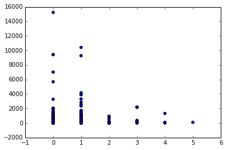

```python
plt.scatter(mentions_followers_df.user_mentions, mentions_followers_df.followers_count)
mentions_followers_df.corr()
```

Perhaps not.

# Lab

## 1-2 Pairs

Raise two fingers if you understand the material well.  
Raise one finger if you understand this material OK.  
Now, 1 find a 2 and sit next to them. While you work through this exercise, only 1's can type.

The [Yahoo! Where On Earth ID](https://developer.yahoo.com/geo/geoplanet/) of Canada is 23424775.  
Use it to find Twitter trends in Canada and compare it to US trends. What's the difference between them?

- Insert the last 100 tweets for all Canada-only trends into a `canada` collection.
- Insert the last 100 tweets for all US-only trends into a `us` collections.
- For this (small and not very representative) sample, which users have the highest `follower_count`?

## Individually:

Find tweets where `'retweet_count': {"$gt": 0}`.  
What is their `count`?  
Is there anything about them that stands out as retweetable?

Further exercises:

- Twitter - *Mining-the-Social-Web-2nd-Edition*: [Chapter 1 - Mining Twitter](http://nbviewer.ipython.org/github/ptwobrussell/Mining-the-Social-Web-2nd-Edition/blob/master/ipynb/__Chapter%201%20-%20Mining%20Twitter%20%28Full-Text%20Sampler%29.ipynb)
- Mongo - [Aggregation Framework](http://docs.mongodb.org/manual/aggregation/)

# Next week: